# Lab 2: Spatial Analysis and Visualization

Healthcare Access and Equity in Pennsylvania

Author

Yiting Zhong

Published

February 22, 2026

## Assignment Overview

**Learning Objectives:** - Apply spatial operations to answer policy-relevant research questions - Integrate census demographic data with spatial analysis - Create publication-quality visualizations and maps - Work with spatial data from multiple sources - Communicate findings effectively for policy audiences

## Part 1: Healthcare Access for Vulnerable Populations

### Research Question

**Which Pennsylvania counties have the highest proportion of vulnerable populations (elderly + low-income) living far from hospitals?**

Your analysis should identify counties that should be priorities for healthcare investment and policy intervention.

**Your Task:**

**Questions to answer:**

- How many hospitals are in your dataset?

  223
- How many census tracts?

  3445
- What coordinate reference system is each dataset in?

  pa_hospitals=WGS 84 ,“EPSG”,4326 pa_tracts=NAD83,“EPSG”,4269 pa_counties=WGS 84,“EPSG”,3857

#### Step 2: Get Demographic Data

**Your Task:**

```r
# Get demographic data from ACS
library(tidycensus)
vars <- c(
  total_pop = "B01001_001",
  med_income = "B19013_001",
  m65_66 = "B01001_020", m67_69 = "B01001_021", m70_74 = "B01001_022",
  m75_79 = "B01001_023", m80_84 = "B01001_024", m85_plus = "B01001_025",
  f65_66 = "B01001_044", f67_69 = "B01001_045", f70_74 = "B01001_046",
  f75_79 = "B01001_047", f80_84 = "B01001_048", f85_plus = "B01001_049"
)
pa_census_data <- get_acs(
  geography = "tract",
  variables = vars,
  state = "PA",
  year = 2022,
  output = "wide"
)
pa_demographics <- pa_census_data %>%
  mutate(
    elderly_pop = rowSums(select(., m65_66E:f85_plusE)),
    elderly_pct = (elderly_pop / total_popE) * 100
  ) %>%
  rename(
    total_population = total_popE,
    median_income = med_incomeE
  ) %>%
  select(GEOID, NAME, total_population, median_income, elderly_pop, elderly_pct)

# Join to tract boundaries
pa_tracts_with_data <- pa_tracts %>%
  left_join(pa_demographics, by = "GEOID")
```

**Questions to answer:**

- What year of ACS data are you using?

  2022
- How many tracts have missing income data?

  62
- What is the median income across all PA census tracts?

  70188

#### Step 3: Define Vulnerable Populations

**Your Task:**

```r
# Filter for vulnerable tracts based on your criteria
pa_valid_data <- pa_tracts_with_data %>%
  filter(!is.na(median_income)) %>%
  filter(total_population > 0)

income_limit <- 55924
elderly_limit<- 37.7


pa_vulnerable_populations <- pa_valid_data %>%
  mutate(
    is_vulnerable = ifelse(
      !is.na(median_income) &
      median_income <= income_limit &
      elderly_pct >= elderly_limit,
      TRUE,
      FALSE
    )
  ) %>%
  filter(is_vulnerable == TRUE)
```

**Questions to answer:**

- What income threshold did you choose and why?

  209/3445=6.07%

#### Step 4: Calculate Distance to Hospitals

For each vulnerable tract, calculate the distance to the nearest hospital.

**Your Task:**

```r
pa_vulnerable_projected <- st_transform(pa_vulnerable_populations, 2272)
pa_hospitals_projected <- st_transform(pa_hospitals, 2272)

vulnerable_centroids <- st_centroid(pa_vulnerable_projected)

distance<- st_distance(vulnerable_centroids,pa_hospitals_projected)

pa_vulnerable_projected$dist_to_hospital_miles <- as.numeric(apply(distance, 1, min)) / 5280
```

**Questions to answer:**

- What is the average distance to the nearest hospital for vulnerable tracts?

  3.538635
- What is the maximum distance?

  19.15822
- How many vulnerable tracts are more than 15 miles from the nearest hospital?

  7

#### Step 5: Identify Underserved Areas

Define “underserved” as vulnerable tracts that are more than 15 miles from the nearest hospital.

**Your Task:**

```r
pa_vulnerable_projected<- pa_vulnerable_projected %>%
  mutate(is_underserved = dist_to_hospital_miles > 15)
```

**Questions to answer:**

- How many tracts are underserved? 7
- What percentage of vulnerable tracts are underserved? 7/209=3.34%
- Does this surprise you? Why or why not? Yes, because there are almost 20,000 of population have to go to hospital that is more than 15 miles away. —

#### Step 6: Aggregate to County Level

Use spatial joins and aggregation to calculate county-level statistics about vulnerable populations and hospital access.

**Your Task:**

```r
# Spatial join tracts to counties
pa_counties_projected <- st_transform(pa_counties, 2272)
vulnerable_with_county <- st_join(pa_vulnerable_projected, pa_counties_projected)

# Aggregate statistics by county
county_summary <- vulnerable_with_county %>%
  group_by(NAMELSADCO) %>%
  summarize(
    num_vulnerable_tracts=n(),
    num_underserved_tracts = sum(is_underserved),
    avg_distance=mean(dist_to_hospital_miles),
    total_vulnerable_population=sum(total_population,na.rm = TRUE))%>%
      mutate(
        pct_vul_tracts_underserved=((num_underserved_tracts / num_vulnerable_tracts)*100)
      )
```

**Questions to answer:**

- Which 5 counties have the highest percentage of underserved vulnerable tracts?

  Forest County, Juniata County, Monroe County, Sullivan County,Dauphin County
- Which counties have the most vulnerable people living far from hospitals?

  Forest County
- Are there any patterns in where underserved counties are located?

  Underserved counties are primarily concentrated in the rural, mountainous central and northern regions of PA, where low population density leads to sparse hospital coverage.

#### Step 7: Create Summary Table

Create a professional table showing the top 10 priority counties for healthcare investment.

**Your Task:**

```r
library(knitr)
# Create and format priority counties table
top_10_counties<-county_summary%>%
  st_drop_geometry()%>%
  arrange(desc(pct_vul_tracts_underserved))%>%
  head(10)%>%
  mutate(
    avg_distance = round(avg_distance, 1)
  )


top_10_counties %>%
  kable(
    col.names = c("County Name", "Vulnerable Tracts", "Underserved Tracts",
                  "Avg. Distance (mi)", "Total Vulnerable Pop", "% Underserved"),
    caption = "Top 10 Pennsylvania Counties Prioritized for Healthcare Investment",
    align = "lccccc"
  )
```

Top 10 Pennsylvania Counties Prioritized for Healthcare Investment

| County Name | Vulnerable Tracts | Underserved Tracts | Avg. Distance (mi) | Total Vulnerable Pop | % Underserved |
| --- | --- | --- | --- | --- | --- |
| Forest County | 4 | 4 | 18.1 | 10804 | 100 |
| Juniata County | 5 | 5 | 15.9 | 8910 | 100 |
| Monroe County | 1 | 1 | 17.7 | 1299 | 100 |
| Sullivan County | 4 | 4 | 16.9 | 3672 | 100 |
| Dauphin County | 4 | 3 | 14.6 | 16446 | 75 |
| Bradford County | 2 | 1 | 9.3 | 8736 | 50 |
| Clearfield County | 4 | 2 | 9.0 | 17256 | 50 |
| Allegheny County | 35 | 0 | 2.3 | 78986 | 0 |
| Armstrong County | 1 | 0 | 3.1 | 2850 | 0 |
| Beaver County | 7 | 0 | 3.1 | 13889 | 0 |

## Part 2: Comprehensive Visualization

Using the skills from Week 3 (Data Visualization), create publication-quality maps and charts.

### Map 1: County-Level Choropleth

Create a choropleth map showing healthcare access challenges at the county level.

**Your Task:**

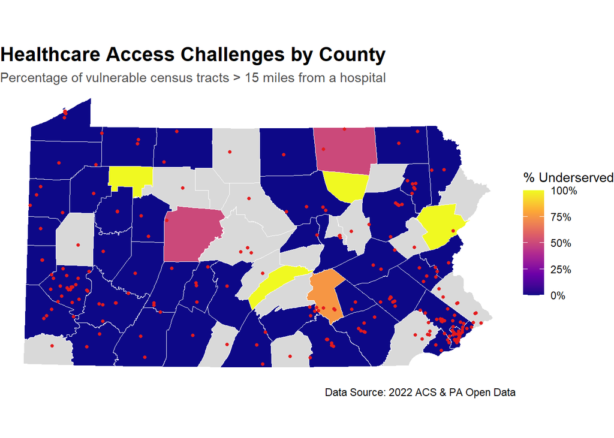

```r
# Create county-level access map
library(sf)
library(ggplot2)
library(tidyverse)

county_summary_clean <- county_summary %>%
  st_drop_geometry() %>%
  mutate(
    join_name = toupper(str_remove_all(NAMELSADCO, "(?i)\\s*COUNTY"))
  )
map1_data <- pa_counties_projected %>%
  mutate(
    join_name =COUNTY_NAM
  ) %>%
  left_join(county_summary_clean, by = "join_name")

ggplot() +
  geom_sf(data = map1_data, aes(fill = pct_vul_tracts_underserved), color = "white", size = 0.3) +
  geom_sf(data = pa_hospitals_projected, color = "#e41a1c", size = 1, alpha = 1) +
  scale_fill_viridis_c(
    name = "% Underserved",
    option = "plasma",
    na.value = "grey85",
    labels = scales::label_percent(scale = 1)
  ) +
  labs(
    title = "Healthcare Access Challenges by County",
    subtitle = "Percentage of vulnerable census tracts > 15 miles from a hospital",
    caption = "Data Source: 2022 ACS & PA Open Data"
  ) +

  theme_void() +
  theme(
    legend.position = "right",
    plot.title = element_text(face = "bold", size = 16),
    plot.subtitle = element_text(size = 11, color = "grey30")
  )
```

### Map 2: Detailed Vulnerability Map

Create a map highlighting underserved vulnerable tracts.

**Your Task:**

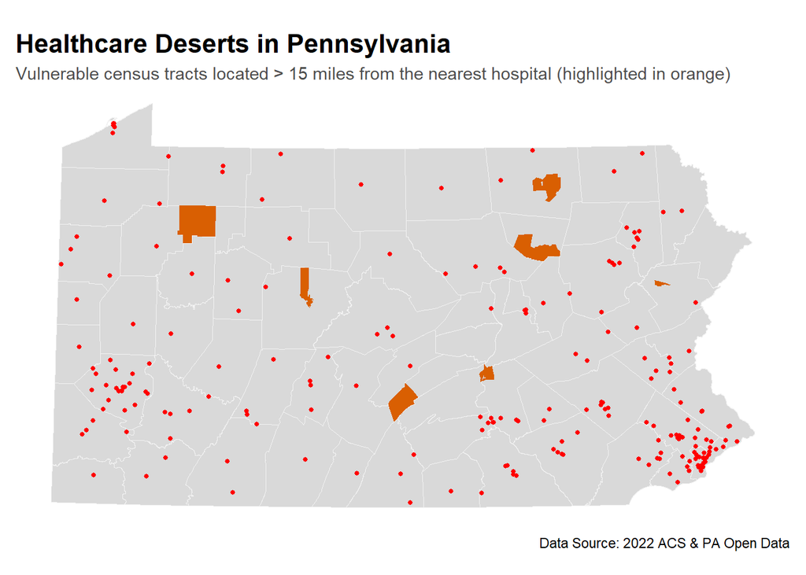

```r
# Create detailed tract-level map
underserved_tracts<-pa_vulnerable_projected%>%
  filter(is_underserved==TRUE)

ggplot()+
  geom_sf(data=pa_counties_projected,fill="grey85",color="grey95",size=0.5)+
    geom_sf(data = underserved_tracts,fill="#d95f02", color = NA)+
    geom_sf(data = pa_hospitals_projected,color="red",size=1)+
labs(
  title = "Healthcare Deserts in Pennsylvania",
  subtitle = "Vulnerable census tracts located > 15 miles from the nearest hospital (highlighted in orange)",
 caption = "Data Source: 2022 ACS & PA Open Data"
)+
  theme_void()+
  theme(
    plot.title = element_text(face = "bold", size = 16),
    plot.subtitle = element_text(size = 11, color = "grey30"),
    plot.margin = margin(10, 10, 10, 10)
  )
```

### Chart: Distribution Analysis

Create a visualization showing the distribution of distances to hospitals for vulnerable populations.

**Your Task:**

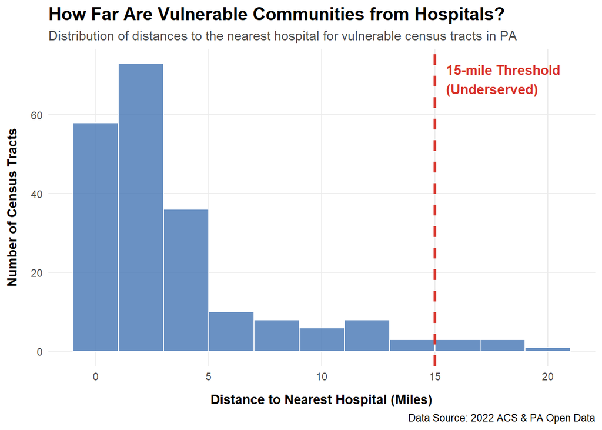

```r
# Create distribution visualization
ggplot(data = pa_vulnerable_projected, aes(x = dist_to_hospital_miles)) +
  geom_histogram(binwidth = 2, fill = "#4575b4", color = "white", alpha = 0.8) +
  geom_vline(xintercept = 15, color = "#d73027", linetype = "dashed", size = 1.2) +
  annotate("text", x = 15.5, y = Inf, label = "15-mile Threshold\n(Underserved)",
           vjust = 1.5, hjust = 0, color = "#d73027", fontface = "bold", size = 4) +
  labs(
    title = "How Far Are Vulnerable Communities from Hospitals?",
    subtitle = "Distribution of distances to the nearest hospital for vulnerable census tracts in PA",
    x = "Distance to Nearest Hospital (Miles)",
    y = "Number of Census Tracts",
    caption = "Data Source: 2022 ACS & PA Open Data"
  ) +
  theme_minimal() +
  theme(
    plot.title = element_text(face = "bold", size = 15),
    plot.subtitle = element_text(size = 11, color = "grey30"),
    axis.title.x = element_text(margin = margin(t = 10), face = "bold"),
    axis.title.y = element_text(margin = margin(r = 10), face = "bold"),
    panel.grid.minor = element_blank()
  )
```

## Part 3: Bring Your Own Data Analysis

#### Environmental Justice

**Green Space Equity** - **Data:** Parks, Street Trees, Census tracts (race/income demographics) - **Question:** “Do low-income and minority neighborhoods have equitable access to green space?”

- **Operations:** Buffer parks (10-minute walk = 0.5 mile), calculate tree canopy or park acreage per capita, compare by demographics
- **Policy relevance:** Climate resilience, environmental justice, urban forestry investment

### Data Sources

**OpenDataPhilly:** https://opendataphilly.org/datasets/

### Your Analysis

**Your Task:**

```r
# Load your additional dataset
library(sf)
library(tidyverse)
phily_Recreation<- st_read("C:/Users/yzhon/OneDrive - PennO365/Penn-Spring 2026/CPLN 592/cpln-5920-sp26-student-portfolio-template/Labs/Lab_2/PPR_Properties.geojson")
print(st_crs(phily_Recreation)$epsg)
```

```
[1] 4326
```

```r
summary(phily_Recreation)
```

```
 public_name        parent_name           nested          official_name
 Length:504         Length:504         Length:504         Length:504
 Class :character   Class :character   Class :character   Class :character
 Mode  :character   Mode  :character   Mode  :character   Mode  :character



    label              alias           dpp_asset_id       address_911
 Length:504         Length:504         Length:504         Length:504
 Class :character   Class :character   Class :character   Class :character
 Mode  :character   Mode  :character   Mode  :character   Mode  :character



   zip_code         address_brt        alias_address         acreage
 Length:504         Length:504         Length:504         Min.   :1.925e-02
 Class :character   Class :character   Class :character   1st Qu.:8.849e-01
 Mode  :character   Mode  :character   Mode  :character   Median :3.563e+00
                                                          Mean   :2.007e+01
                                                          3rd Qu.:8.215e+00
                                                          Max.   :1.683e+03
 property_classification   ppr_use          ppr_prog_district
 Length:504              Length:504         Length:504
 Class :character        Class :character   Class :character
 Mode  :character        Mode  :character   Mode  :character



 ppr_ops_district   council_district   police_district    city_scale_maps
 Length:504         Length:504         Length:504         Length:504
 Class :character   Class :character   Class :character   Class :character
 Mode  :character   Mode  :character   Mode  :character   Mode  :character



 local_scale_maps   program_sites        comments            objectid
 Length:504         Length:504         Length:504         Min.   :  1.0
 Class :character   Class :character   Class :character   1st Qu.:126.8
 Mode  :character   Mode  :character   Mode  :character   Median :252.5
                                                          Mean   :252.5
                                                          3rd Qu.:378.2
                                                          Max.   :504.0
  Shape__Area        Shape__Length               geometry
 Min.   :1.328e+02   Min.   :   57.99   MULTIPOLYGON :504
 1st Qu.:6.102e+03   1st Qu.:  361.78   epsg:4326    :  0
 Median :2.467e+04   Median :  715.52   +proj=long...:  0
 Mean   :1.387e+05   Mean   : 1721.22
 3rd Qu.:5.667e+04   3rd Qu.: 1228.31
 Max.   :1.164e+07   Max.   :91233.29
```

**Questions to answer:**

- What dataset did you choose and why?

  I used PPR_Properties.geojson,I selected this to analyze green space equity (Option C), as access to public parks is a crucial indicator of public health and urban environmental quality.
- What is the data source and date?

  The data is sourced from OpenDataPhilly, not sure the exact date.
- How many features does it contain?

  504
- What CRS is it in? Did you need to transform it?

  4326,yes, I change to 2272(PA south).
2. **Pose a research question**

Do vulnerable census tracts in Philadelphia have equitable walking access to public parks and green spaces?

3. **Conduct spatial analysis**

**Your Task:**

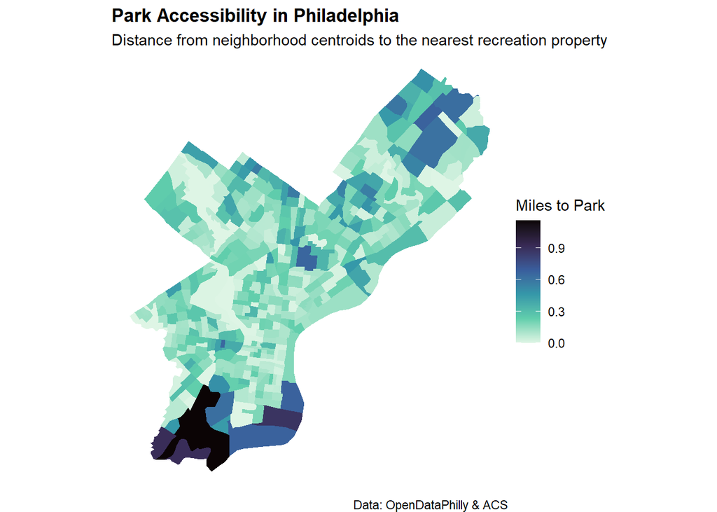

```r
# Your spatial analysis
phily_Recreation_projected<- st_transform(phily_Recreation,2272)

philly_tracts<- pa_tracts_with_data %>%
  filter(str_detect(NAMELSADCO,"Philadelphia County"))%>%
  st_transform(2272)

philly_centroids<- st_centroid(philly_tracts)

parks_unioned <- st_union(phily_Recreation_projected)

park_to_tracts <- st_distance(philly_centroids, parks_unioned)

philly_tracts$dist_to_park_miles <- as.numeric(park_to_tracts) / 5280

ggplot() +
  geom_sf(data = philly_tracts, aes(fill = dist_to_park_miles), color = NA) +
  scale_fill_viridis_c(
    name = "Miles to Park",
    option = "mako",
    direction = -1
  ) +
  labs(
    title = "Park Accessibility in Philadelphia",
    subtitle = "Distance from neighborhood centroids to the nearest recreation property",
    caption = "Data: OpenDataPhilly & ACS"
  ) +
  theme_void() +
  theme(plot.title = element_text(face = "bold"))
```

```r
library(knitr)
library(dplyr)

park_access_summary <- philly_tracts %>%
  st_drop_geometry() %>%
  mutate(
    access_level = case_when(
      dist_to_park_miles <= 0.5 ~ "0 - 0.5 miles (Excellent Walkability)",
      dist_to_park_miles > 0.5 & dist_to_park_miles <= 1.0 ~ "0.5 - 1.0 miles (Good)",
      dist_to_park_miles > 1.0 & dist_to_park_miles <= 2.0 ~ "1.0 - 2.0 miles (Fair)",
      dist_to_park_miles > 2.0 ~ "> 2.0 miles (Park Desert)",
      TRUE ~ "Unknown"
    )
  ) %>%
  group_by(access_level) %>%
  summarize(
    number_of_tracts = n()
  ) %>%
  mutate(
    percentage = paste0(round((number_of_tracts / sum(number_of_tracts)) * 100, 1), "%")
  )
park_access_summary %>%
  kable(
    col.names = c("Distance to Nearest Park", "Number of Tracts", "Percentage (%)"),
    caption = "Distribution of Park Accessibility across Philadelphia Census Tracts",
    align = "lcc"
  )
```

Distribution of Park Accessibility across Philadelphia Census Tracts

| Distance to Nearest Park | Number of Tracts | Percentage (%) |
| --- | --- | --- |
| 0 - 0.5 miles (Excellent Walkability) | 390 | 95.6% |
| 0.5 - 1.0 miles (Good) | 17 | 4.2% |
| 1.0 - 2.0 miles (Fair) | 1 | 0.2% |

**Your interpretation:**

Based on the spatial analysis, basic park accessibility in Philadelphia is exceptionally high. The summary statistics reveal that 95.6% of census tracts enjoy “Excellent Walkability”, being located within a 0.5-mile radius of a recreation property.However, the map highlights specific spatial gaps primarily in the extreme southern and far northeastern edges of the city. From a planning perspective, these are largely driven by distinct land-use patterns: the deep south is dominated by industrial zones and the Philadelphia International Airport (where residential population is minimal), while the Far Northeast features a more suburban, auto-oriented built environment where residents often have access to private yards, reducing the historical demand for dense public pocket parks. Overall, the city demonstrates strong spatial equity in baseline park access.